# Лабораторна робота 2

Перш за все, встановимо та приєднаємо необхідні пакети.

```r
install.packages("data.table")
install.packages("dplyr")
library(data.table)
library(dplyr)
```

Далі, встановлення робочої директорії.

```r
setwd('/Users/v.zusko/Desktop/r/lab-2')
```

Завантажимо базові дані (`NEI`, `SCC`).

```r
NEI <- readRDS("summarySCC_PM25.rds")
SCC <- readRDS("Source_Classification_Code.rds")
```

Об’єднаємо дані в один датафрейм.

```r
merged_data <- inner_join(NEI, SCC, by = "SCC")
```

Проаналізуємо чи зменшилися загальні викиди PM2.5 у Сполучених Штатах з 1999 по 2008 рік. Для цього використаємо функцію `filter` для вибору даних за вказаний період, а потім обчислимо загальні викиди PM2.5 для кожного року. Нанесемо результати на графік.

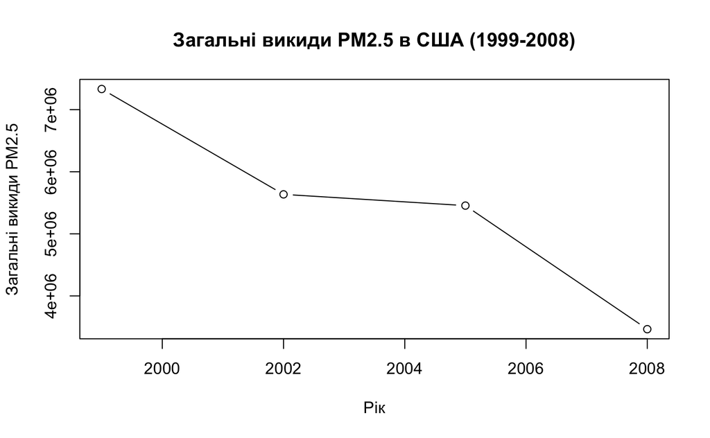

```r
filtered_data <- filter(merged_data, year >= 1999 & year <= 2008)
pm25_by_year <- summarize(group_by(filtered_data, year), total_pm25 = sum(Emissions))


plot(
  pm25_by_year$year,
  pm25_by_year$total_pm25,
  type = "b",
  xlab = "Рік",
  ylab = "Загальні викиди PM2.5",
  main = "Загальні викиди PM2.5 в США (1999-2008)"
)
```

Проаналізуємо чи зменшилися загальні викиди PM2.5 у місті Балтимор, штат Меріленд з 1999 по 2008 рік. Нанесемо результати на графік.

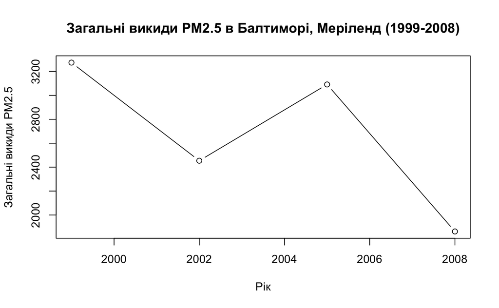

```r
baltimore_fips = "24510"
baltimore_data <- filter(merged_data, fips == baltimore_fips & year >= 1999 & year <= 2008)
baltimore_pm25_by_year <- summarize(group_by(baltimore_data, year), total_pm25 = sum(Emissions))

plot(
  baltimore_pm25_by_year$year,
  baltimore_pm25_by_year$total_pm25,
  type = "b",
  xlab = "Рік",
  ylab = "Загальні викиди PM2.5",
  main = "Загальні викиди PM2.5 в Балтиморі, Меріленд (1999-2008)"
)
```

Додамо груповані за роком та джерелом дані. Для кожного типу джерела побудуємо графік.

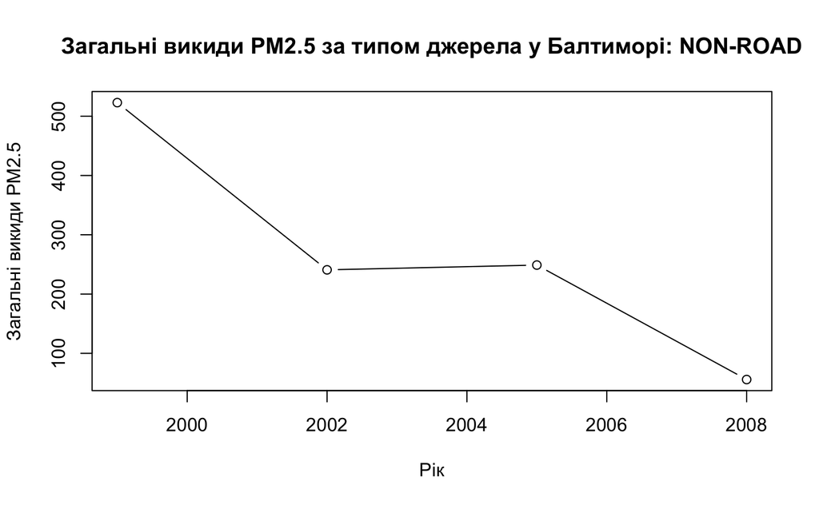

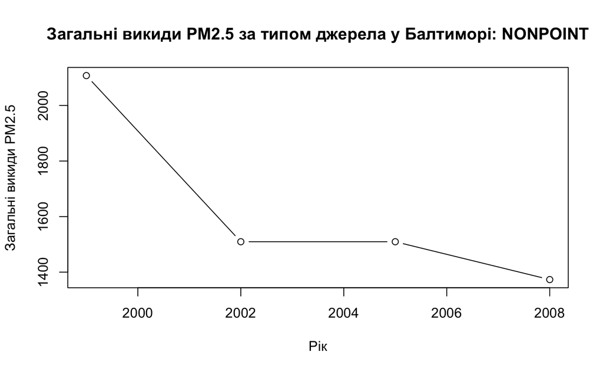

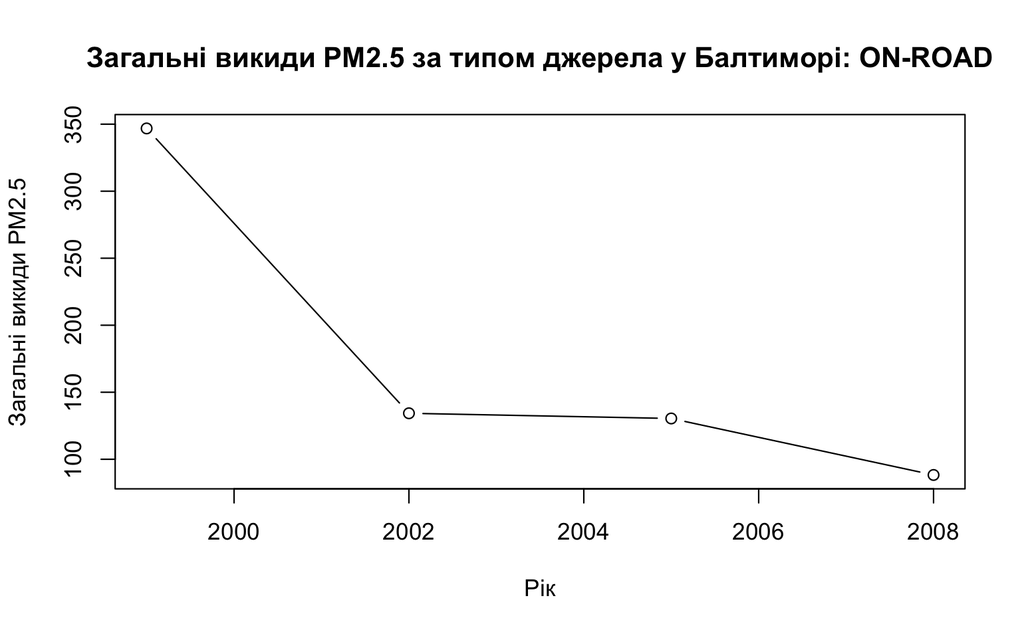

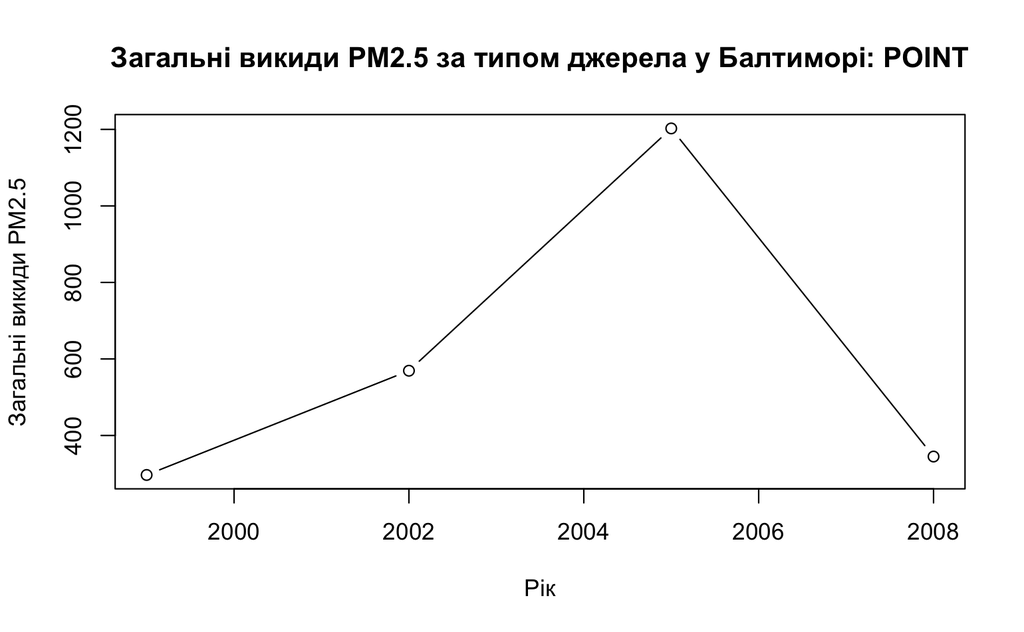

```r
baltimore_pm25_by_source_and_year <- summarize(
  group_by(baltimore_data, type, year),
  baltimore_total_pm25 = sum(Emissions),
  .groups = "drop"
)

for (source_type in unique(baltimore_pm25_by_source_and_year$type)) {
  baltimore_subset_data <- filter(baltimore_pm25_by_source_and_year, type == source_type)

  plot(
    baltimore_subset_data$year,
    baltimore_subset_data$baltimore_total_pm25,
    type = "b",
    xlab = "Рік",
    ylab = "Загальні викиди PM2.5",
    main = paste("Загальні викиди PM2.5 за типом джерела у Балтиморі:", source_type)
  )
}
```

Додатково, визначимо типи джерел, в яких спостерігалося зменшення і збільшення викидів у Балтиморі.

```r
baltimore_decreasing_sources <- baltimore_pm25_by_source_and_year %>%
  group_by(type) %>%
  summarize(min_year = min(year), max_year = max(year),
            total_change = sum(diff(baltimore_total_pm25))) %>%
  filter(total_change < 0)

cat("Типи джерел, де спостерігалося зменшення викидів:", baltimore_decreasing_sources$type, "\n")
```

```
Типи джерел, де спостерігалося зменшення викидів: NON-ROAD NONPOINT ON-ROAD
```

```r
baltimore_increasing_sources <- baltimore_pm25_by_source_and_year %>%
  group_by(type) %>%
  summarize(min_year = min(year), max_year = max(year),
            total_change = sum(diff(baltimore_total_pm25))) %>%
  filter(total_change > 0)

# Виведення результатів
cat("Типи джерел, де спостерігалося зростання викидів:", baltimore_increasing_sources$type, "\n")
```

```
Типи джерел, де спостерігалося зростання викидів: POINT
```

Проаналізуємо викиди PM2.5 від джерел, пов’язаних зі спалюванням вугілля в США з 1999 по 2008 рік. Нанесемо результати на графік.

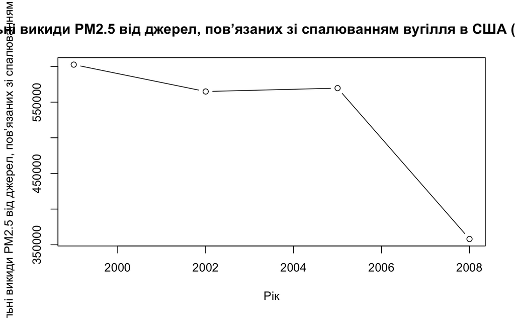

```r
coal_data <- filter(merged_data, grepl("coal", merged_data$Short.Name, ignore.case = TRUE))
coal_data <- filter(coal_data, year >= 1999 & year <= 2008)

coal_pm25_by_year <- summarize(group_by(coal_data, year), total_pm25 = sum(Emissions))

plot(coal_pm25_by_year$year, coal_pm25_by_year$total_pm25, type = "b",
     xlab = "Рік", ylab = "Загальні викиди PM2.5 від джерел, пов’язаних зі спалюванням вугілля",
     main = "Загальні викиди PM2.5 від джерел, пов’язаних зі спалюванням вугілля в США (1999-2008)")
```

Проаналізуємо викиди PM2.5 від джерел автотранспорту в місті Балтимор з 1999 по 2008 рік. Для цього використаємо функцію `filter` для вибору даних за вказаний період та вказаним типом джерела, а потім обчислимо загальні викиди PM2.5 для кожного року. Нанесемо результати на графік.

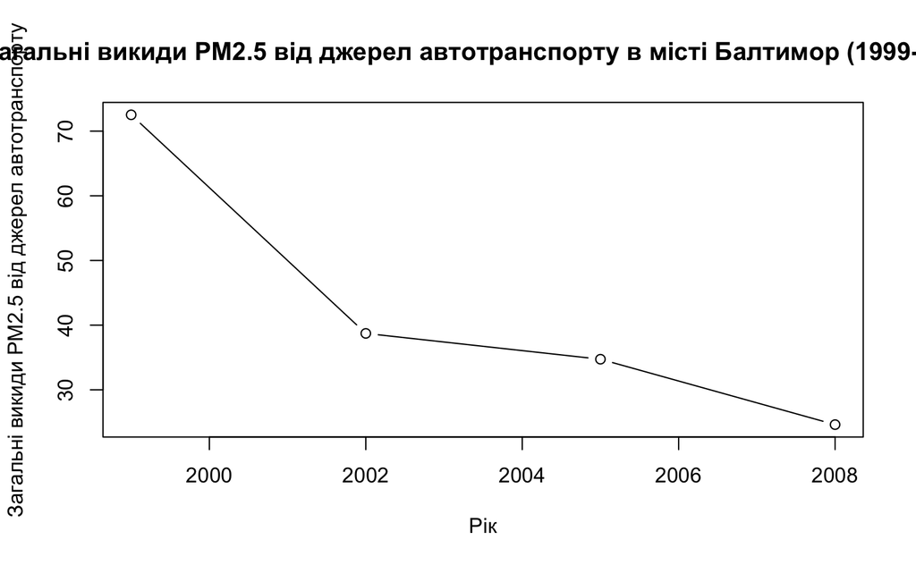

```r
vehicle_emissions_baltimore_data <- filter(baltimore_data, grepl("vehicle", baltimore_data$Short.Name, ignore.case = TRUE))

vehicle_emissions_baltimore_pm25_by_year <- summarize(
  group_by(vehicle_emissions_baltimore_data, year),
  baltimore_total_pm25 = sum(Emissions)
)

plot(
  vehicle_emissions_baltimore_pm25_by_year$year,
  vehicle_emissions_baltimore_pm25_by_year$baltimore_total_pm25,
  type = "b",
  xlab = "Рік",
  ylab = "Загальні викиди PM2.5 від джерел автотранспорту",
  main = "Загальні викиди PM2.5 від джерел автотранспорту в місті Балтимор (1999-2008)"
)
```

Порівняємо викиди PM2.5 від джерел автотранспорту в місті Балтимор та Лос-Анджелес з 1999 по 2008 рік. Нанесемо результати на графік. Також, виведемо результати порівняння.

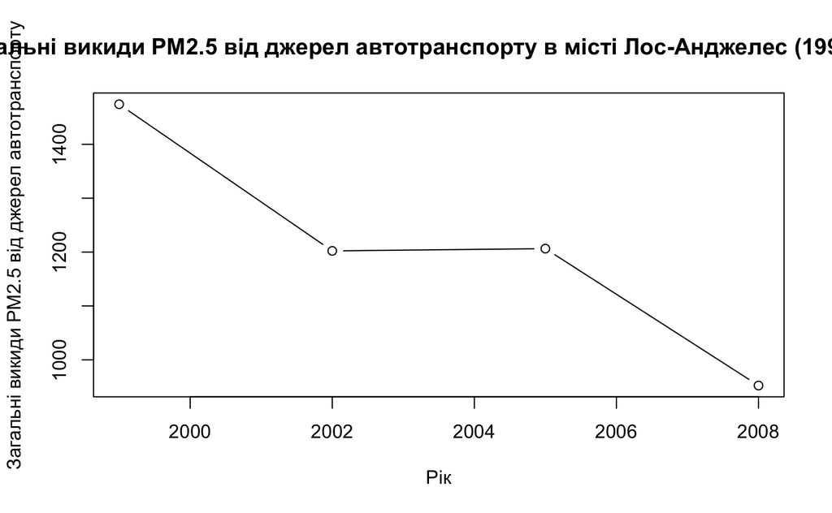

```r
los_angeles_fips = "06037"
los_angeles_data <- filter(merged_data, fips == los_angeles_fips & year >= 1999 & year <= 2008)
vehicle_emissions_los_angeles_data <- filter(los_angeles_data, grepl("vehicle", los_angeles_data$Short.Name, ignore.case = TRUE))
vehicle_emissions_los_angeles_pm25_by_year <- summarize(
  group_by(vehicle_emissions_los_angeles_data, year),
  los_angeles_total_pm25 = sum(Emissions)
)

plot(
  vehicle_emissions_los_angeles_pm25_by_year$year,
  vehicle_emissions_los_angeles_pm25_by_year$los_angeles_total_pm25,
  type = "b",
  xlab = "Рік",
  ylab = "Загальні викиди PM2.5 від джерел автотранспорту",
  main = "Загальні викиди PM2.5 від джерел автотранспорту в місті Лос-Анджелес (1999-2008)"
)
```

```r
comparison <- mutate(
  inner_join(vehicle_emissions_baltimore_pm25_by_year, vehicle_emissions_los_angeles_pm25_by_year, by = "year"),
  change_baltimore = baltimore_total_pm25 - lag(baltimore_total_pm25),
  change_los_angeles = los_angeles_total_pm25 - lag(los_angeles_total_pm25)
)

print(comparison)
```

| year | baltimore_total_pm25 | los_angeles_total_pm25 | change_baltimore | change_los_angeles |
| --- | --- | --- | --- | --- |
| 1999 | 72.52000 | 1474.3960 | NA | NA |
| 2002 | 38.72593 | 1202.2272 | -33.794075 | -272.16883 |
| 2005 | 34.73461 | 1206.4067 | -3.991312 | 4.17957 |
| 2008 | 24.62275 | 952.3045 | -10.111863 | -254.10226 |